# itdr-vignette

## Chapter 3: Functions related with estimating the central mean subspace using Iterative Hessian Transformation (IHT)

The `itdr()` function extends its utility to estimating the central mean subspace in regression through the iterative Hessian transformation (IHT) method. The following R chunk illustrates the application of this method on the `Recumbent` dataset available within the **itdr** package. Notice that the function requires inputs such as the method of estimation (`method=iht`), the response vector (y), the design matrix of predictors (x), and the dimension (d) of the CMS. These choices for the response and predictors align with those of Cook and Li (2002).

```r
library(itdr)
data("recumbent")
recumbent.na <- na.omit(recumbent)
y <- recumbent.na$outcome
X1 <- log(recumbent.na$ast)
X2 <- log(recumbent.na$ck)
X3 <- log(recumbent.na$urea)
p <- 3
x <- matrix(c(X1, X2, X3), ncol = p)
d <- 2
fit.iht_CMS <- itdr(y, x, 2, method = "iht")
fit.iht_CMS$eta_hat
```

```
#>            [,1]        [,2]
#> [1,]  0.3260269  0.95986216
#> [2,] -0.2395713 -0.27884564
#> [3,] -0.9145010  0.03016189
```

## Chapter 4: Estimating the Central Subspace in Regression using Fourier Transformation Approach on Inverse Dimension Reduction

In this section, we demonstrate the functions within the **itdr** package related to the Fourier transformation approach on inverse dimension reduction. Section 4.1 illustrates the use of function to estimate the dimension of the central subspace using the Fourier transformation approach on inverse dimension reduction, while Section 4.2 outlines the estimation process for the CS itself.

### 4.1: Estimating d

The estimation of the dimension of the CS can be achieved using the `d.test()` function which provides outputs of three different p-values for three different test statistics: the Weighted Chi-square test statistic (Weng and Yin, 2018), the Scaled test statistic (Bentler and Xie, 2000), and the Adjusted test statistic (Bentler and Xie, 2000). Suppose `m` is the candidate dimension of the CS to be tested `(H_0: d=m)`, then the following R code demonstrates testing a candidate value `m` (<p) for dimension of the CS of the planning database (PDB).

```r
library(itdr)
data(pdb)
colnames(pdb) <- NULL
p <- 15
# select predictor vecotr (y) and response variables (X) according to Weng and Weng and Yin, (2018).
df <- pdb[, c(79, 73, 77, 103, 112, 115, 124, 130, 132, 145, 149, 151, 153, 155, 167, 169)]
dff <- as.matrix(df)
# remove the NA rows
planingdb <- dff[complete.cases(dff), ]

y <- planingdb[, 1] # n-dimensionl response vector
x <- planingdb[, c(2:(p + 1))] # raw desing matrix
x <- x + 0.5
# desing matrix after tranformations
xt <- cbind(
  x[, 1]^(.33), x[, 2]^(.33), x[, 3]^(.57), x[, 4]^(.33), x[, 5]^(.4),
  x[, 6]^(.5), x[, 7]^(.33), x[, 8]^(.16), x[, 9]^(.27), x[, 10]^(.5),
  x[, 11]^(.5), x[, 12]^(.33), x[, 13]^(.06), x[, 14]^(.15), x[, 15]^(.1)
)
m <- 1
W <- sapply(50, rnorm)
# run the hypothsis tests
d.test(y, x, m)
```

```
#>   Hypothesis Tests for selecting sufficient dimension (d)
#>  Null: d=m    vs  Alternative: d>m
#>
#>  Test         W.Ch.Sq         Scaled      Adjusted
#>  p-value      0.9402      1       0.8940887
```

### 4.2: Estimating central subspace

After selecting the dimension of the CS as described in Section 4.1, then, an estimator for the CS can be obtained using the `itdr()` function. The following R chunk illustrates the use of the `itdr()` function to estimate the CS for planning database (PDB).

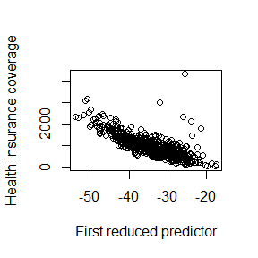

```r
library(itdr)
data(pdb)
colnames(pdb) <- NULL
p <- 15
# select predictor vecotr (y) and response variables (X) according to Weng and Weng and Yin, (2018).
df <- pdb[, c(79, 73, 77, 103, 112, 115, 124, 130, 132, 145, 149, 151, 153, 155, 167, 169)]
dff <- as.matrix(df)
# remove the NA rows
planingdb <- dff[complete.cases(dff), ]

y <- planingdb[, 1] # n-dimensionl response vector
x <- planingdb[, c(2:(p + 1))] # raw desing matrix
x <- x + 0.5
# desing matrix after tranformations give in Weng and Yin, (2018).
xt <- cbind(
  x[, 1]^(.33), x[, 2]^(.33), x[, 3]^(.57), x[, 4]^(.33), x[, 5]^(.4),
  x[, 6]^(.5), x[, 7]^(.33), x[, 8]^(.16), x[, 9]^(.27), x[, 10]^(.5),
  x[, 11]^(.5), x[, 12]^(.33), x[, 13]^(.06), x[, 14]^(.15), x[, 15]^(.1)
)

d <- 1 # estimated dimension of the CS from Section 4.1
invFM.fit <- itdr(y, x, d, m = 50, method = "invFM", x.scale = FALSE) # estimated basis
betahat <- invFM.fit$eta_hat

plot(y ~ xt %*% betahat,
  xlab = "First reduced predictor",
  ylab = "Health insurance coverage"
)
```

Ensure accurate specification of inputs and follow methodological guidelines for reliable estimation.

## Chapter 5: A Minimum Discrepancy Approach with Fourier Transfrom in Sufficient Dimension Reduciton

```r
library(itdr)
data(prostate)
X <- as.matrix(prostate[, 1:8])
Y <- matrix(prostate[, 9], ncol = 1)
fit.ftire <- mitdr(X, Y, d = 2, m = 10, method = "FT-IRE")
betahat <- fit.ftire$Beta_hat
betahat
```

```
#>              [,1]         [,2]
#> [1,] -0.643969773 -0.090157354
#> [2,] -0.619511855 -0.255375233
#> [3,]  0.014352745 -0.009681973
#> [4,] -0.136341586 -0.078471708
#> [5,] -0.327797541  0.911485848
#> [6,]  0.165756437  0.043752020
#> [7,] -0.218516733 -0.296112877
#> [8,] -0.006080828  0.000257746
```

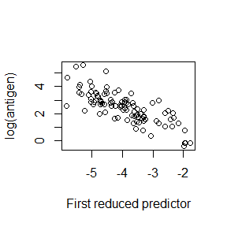

```r
newx <- X %*% betahat
plot(Y ~ newx[, 1],
  xlab = "First reduced predictor",
  ylab = paste0(expression(log), "(antigen)", sep = "")
)
```

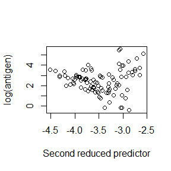

```r
plot(Y ~ newx[, 2],
  xlab = "Second reduced predictor",
  ylab = paste0(expression(log), "(antigen)", sep = "")
)
```

## Chapter 6: Fourier Transform Sparse Inverse Regression Estimators for Sufficient Variable Selection

```r
data(raman)
Y <- as.matrix(raman[, c(1100)]) ## percentage of total fat content
X <- as.matrix(raman[c(2:501)]) ## first 500 wavelength variables
out <- mitdr(X, Y, d = 1, m = 30, method = "admmft", lambda = 0.5, sparse.cov = TRUE, x.scale = TRUE)
estbeta <- out$Beta_hat
estbeta
```

```
#>                 [,1]
#>   [1,]  0.000000e+00
#>   [2,]  0.000000e+00
#>   [3,]  0.000000e+00
#>   [4,]  0.000000e+00
#>   [5,]  0.000000e+00
#>   [6,]  0.000000e+00
#>   [7,]  0.000000e+00
#>   [8,]  0.000000e+00
#>   [9,]  0.000000e+00
#>  [10,]  0.000000e+00
#>  [11,]  0.000000e+00
#>  [12,]  0.000000e+00
#>  [13,]  0.000000e+00
#>  [14,]  0.000000e+00
```

[output cut: 486 more lines]

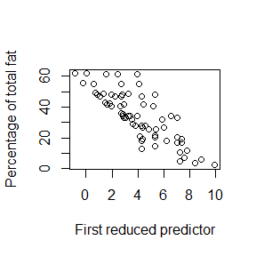

```r
plot(Y ~ X %*% estbeta,
  xlab = "First reduced predictor",
  ylab = "Percentage of total fat"
)
```

## Acknowledgment

The codes for the Fourier transformation and the convolution transformation methods have been adapted from the codes provided by Zhu and Zeng (2006). Moreover, the methods for handling elliptically contoured distributed variables and kernel density estimation are essentially modifications of the programs originally provided by Zeng and Zhu (2010). Furthermore, the code for Fourier transforms approach for the inverse dimension reduction method has been adapted from the code provided by Weng and Yin (2018).

## References

- Bentler, P.M., and Xie, J. (2000). Corrections to Test Statistics in Principal Hessian Directions. *Statistics and Probability Letters*. 47, 381-389.
- Cook R. D., and Li, B., (2002). Dimension Reduction for Conditional Mean in Regression. *The Annals of Statitics*, 30, 455-474.
- Stamey, T. A., Kabalin, J. N., McNeal, J. E., Johnstone, I. M., Freiha, F., Redwine, E. A. et al. (1989). Prostate specific antigen in the diagnosis and treatment of adenocarcinoma of the prostate. II. Radical prostatectomy treated patients. *The Journal of Urology*, 141, 1076-1083.
- Weng, J.(2022). Fourier transform sparse inverse regression estimators for sufficient variable selection, *Computational Statistics & Data Analysis*, 168,107380.
- Weng, J., & Yin, X. (2022). A minimum discrepancy approach with fourier transform in sufficient dimension reduction. *Stat. Sin.*, 32.
- Weng J. and Yin X. (2018). Fourier Transform Approach for Inverse Dimension Reduction Method. *Journal of Nonparametric Statistics*. 30, 4, 1029-0311.
- Zeng P. and Zhu Y. (2010). An Integral Transform Method for Estimating the Central Mean and Central Subspaces. *Journal of Multivariate Analysis*. 101, 271–290.
- Zhu Y. and Zeng P. (2006). Fourier Methods for Estimating the Central Subspace and Central Mean Subspace in Regression. *Journal of the American Statistical Association*. 101, 1638–1651.